# Import and Manage CHOP Study Data

- Show All Code
- Hide All Code
- View Source

CSTAT Case: C1358  
Client: Masyr, Alison

Authors

Affiliation

Steven J. Pierce

Michigan State University, Center for Statistical Training and Consulting

Ruxin Shi

Michigan State University, Center for Statistical Training and Consulting

Published

2026-01-29 13:45:50 EST

Modified

2026-01-26 13:39:45 EST

# 1 Purpose

This file is part of a research compendium (Pierce, 2026). It imports raw data provided by Alison Masyr and Caitlin Eliason that contains observations of dogs receiving CHOP chemotherapy at MSU Veterinary Medicine Clinic (VMC) between 2016 and 2022. This file does some data cleaning and management, then saves out revised data files that will be used for the analyses in other scripts. These data will be used in a manuscript (Eliason et al., 2026).

**Caution**

- Rendering this script will overwrite the `data/Imported_CHOP_Data.RData` file in your local repository regardless of whether you are rendering the HTML output to a draft file or to a date-stamped production output file.
- Consider copying that file to a new file name before you render this script if you want to retain the original version I published with this package. Alternatively, you should also be able to download my original version from GitHub.

# 2 Setup

This section documents some setup tasks that are useful to the statistician on the team. Most readers of this document will probably want skip directly to Section 3.

## 2.1 Define Global Options

Global R chunk options are defined in the YAML header but local chunk options will over-ride global options. We can temporarily disable an individual chunk by inserting `#| eval: false` on a line at the top of the chunk.

## 2.2 Load Packages

Load R packages that we need to get additional functions.

````markdown
```{r}
#| label: load-packages
library(devtools)     # for session_info()
```
```{r}
#| label: load-packages
library(dplyr)      # for filter(), group_by(), mutate(), rename(), summarise()
```
```{r}
#| label: load-packages
library(here)       # for here(), i_am()
```
````

```
here() starts at P:/Consulting/Cases_1200-1399/C1358/CHOPStudy/scripts
```

````markdown
```{r}
#| label: load-packages
library(knitr)      # for kable()
library(kableExtra) # for kable_styling
```
```{r}
#| label: load-packages
library(labelled)   # for set_variable_labels()
library(readxl)     # for read_xlsx()
library(piercer)    # for file_details(), git_report()
library(quarto)     # for quarto_version()
library(CHOPStudy)  # for version info
```
````

## 2.3 Declare Path

````markdown
```{r}
#| label: declare-path

here::i_am(path = "scripts/Import_Data.qmd")
```
````

```
here() starts at P:/Consulting/Cases_1200-1399/C1358/CHOPStudy
```

## 2.4 Read Data

**Note**

As a final stage of preparing the repository for public release, we replaced the data file `Vinc_Cases_2026-01-16.xlsx` with `Vinc_Cases_2026-01-26.xlsx`. The only change to the data file was removing the `MRN` variable containing medical record numbers. We had previously verified that the `Patient` variable is a suitably de-identified replacement for `MRN`: they have a one-to-one correspondence, but while `MRN` values appear in actual clinic records, the `Patient` values do not). The file containing `MRN` files is being retained by the team as private documentation and will not be shared publicly.

Table 1 shows meta-data about the raw data file we will import.

````markdown
```{r}
#| label: tbl-raw-data-file
#| tbl-cap: "Meta-Data About Raw Data File"

# Store path to raw data file.
RawFile <- here("scripts/extdata/Vinc_Cases_2026-01-26.xlsx")

file_details(RawFile) %>%
  kable(, format = "html",
        col.names = c("File Name", "Size", "Last Modified")) %>%
  kable_styling()
```
````

Table 1: Meta-Data About Raw Data File

| File Name | Size | Last Modified |
| --- | --- | --- |
| Vinc_Cases_2026-01-26.xlsx | 138K | 2026-01-26 12:01:30 |

Below we read in the data file and then list the names of all variables in that file.

````markdown
```{r}
#| label: import-data

Raw_Visits <- read_xlsx(RawFile)
names(Raw_Visits)
```
````

```
 [1] "Patient"               "Age_Yrs"               "Sex"
 [4] "Breed"                 "Diagnosis"             "Stage"
 [7] "Substage"              "Phenotype"             "In_Final_Patients"
[10] "In_Final_Visits"       "Visit_Number"          "CHOP_Start_Date"
[13] "Phase_of_Trt"          "CHOP_Number"           "CBC_Date"
[16] "Total_WBC"             "Total_Neutrophil"      "Total_Bands"
[19] "Bandemia_Grade"        "Sick_Type"             "Drug"
[22] "Dose_mgpm2"            "Weight_kg"             "Surface_Area_m2"
[25] "Steroid1_Type"         "Steroid1_Date_Started" "Steroid2_Type"
[28] "Steroid2_Date_Started" "Leukemic"              "Toxic_Change"
[31] "Notes"
```

# 3 Data Management

The first task is just renaming variables. After that, we also need to convert some variables to factors and compute some additional variables.

The units of measurement for `Total_Bands` are 1000/ul (k/ul) and some are not integers (they have non-zero digits to the right of the decimal place). Therefore, we rescaled into a new variable that has units of 100/ul by computing `Total_Bands_Rescale = Total_Bands*10`. That rescaled variable was used in draft count models we ultimately abandoned. We decided to focus on a logistic model instead of the count model. The variables and some associated descriptive analyses remain in the repository, but we never added the count model to the repository.

We also created log transformed versions of both `Total_Bands` and `Total_Bands_Rescaled` for use in graphing data. Because `log(0) = -Infinity`, we recode the `-Infinity` values for `log_Total_Bands` to -5 and the `-Infinity` values for `log_Total_Bands_Rescaled` to -3 so that we can make compact graphs of the distributions. Do not use those two variables for descriptive statistics or models because they don’t correctly represent the infinite values properly for other purposes. These variables and associated descriptive analyses are also no longer part of our manuscript plans but we just left the code for them in the data management and descriptive analyses.

The code below does some data management, then lists the names of variables again.

````markdown
```{r}
#| label: create-All-Visits

All_Visits <- Raw_Visits %>%
  mutate(Patient = factor(Patient),
         Days_Since_Start = as.numeric(CBC_Date - CHOP_Start_Date, units = "days"),
         Weeks = Days_Since_Start/7,
         Total_Bands_Rescaled = Total_Bands*10,
         # Special recoded log variables for use only in graphs!
         log_Total_Bands = if_else(Total_Bands == 0,
                                   true = -5,
                                   false = log(Total_Bands)),
         log_Total_Bands_Rescaled = if_else(Total_Bands_Rescaled == 0,
                                   true = -3,
                                   false = log(Total_Bands_Rescaled)),
         # Binary transformations of Total_Bands.
         Bands_Present = if_else(Total_Bands > 0, true = 1, false = 0),
         Bandemia = if_else(Total_Bands > 0.1, true = 1, false = 0),
         # Categorize Total_Bands.
         Band_Category = factor(case_when(Total_Bands == 0 ~ 1,
                                          Total_Bands <= 0.1 ~ 2,
                                          Total_Bands > 0.1 ~ 3),
                                levels = 1:3,
                                labels = c("Absent (0.0 k/ul)",
                                           "Present (<= 0.1 k/ul)",
                                           "Bandemia (> 0.1 k/ul)")),
         # Recode Toxic_Change
         Toxic_Change = if_else(Toxic_Change == "yes", true = 1, false = 0),
         # Band:Neutrophil ratio transformations.
         BN_Ratio = Total_Bands/Total_Neutrophil,
         High_BN_Ratio = if_else(BN_Ratio >= 1, true = 1, false = 0),
         # Add drug name
         Name = factor(Drug, levels = 1:3,
                       labels = c("Vincristine", "Cyclophosphamide",
                                  "Doxorubicin")),
         # Add neutered variable, then fix Sex variable.
         Neutered = factor(case_when(Sex %in% c("F","M") ~ "Intact",
                                     Sex == "N" ~ "Neutered",
                                     Sex == "S" ~ "Spayed",
                                     .default = NA)),
         Sex = factor(case_when(Sex == "N" ~ "M",
                                Sex == "S" ~ "F",
                                .default = Sex)),
         Sick_Type = factor(Sick_Type, levels = c("Not sick", "Self-limited",
                                                  "Medicated", "Hospitalized")),
         Is_Sick = if_else(Sick_Type == "Not sick", true = 0, false = 1,
                           missing = NA),
         # Fix handling of missing data.
         Stage = if_else(Stage == "N/A",
                         true = NA,
                         false = Stage),
         Substage = if_else(Substage == "N/A",
                            true = NA,
                            false = Substage),
         Phenotype = if_else(Phenotype == "N/A",
                             true = NA,
                             false = Phenotype)) %>%
  arrange(Patient, CHOP_Number, Visit_Number, CBC_Date)

# Show the updated variable names to confirm all looks right.
names(All_Visits)
```
````

```
 [1] "Patient"                  "Age_Yrs"
 [3] "Sex"                      "Breed"
 [5] "Diagnosis"                "Stage"
 [7] "Substage"                 "Phenotype"
 [9] "In_Final_Patients"        "In_Final_Visits"
[11] "Visit_Number"             "CHOP_Start_Date"
[13] "Phase_of_Trt"             "CHOP_Number"
[15] "CBC_Date"                 "Total_WBC"
[17] "Total_Neutrophil"         "Total_Bands"
[19] "Bandemia_Grade"           "Sick_Type"
[21] "Drug"                     "Dose_mgpm2"
[23] "Weight_kg"                "Surface_Area_m2"
[25] "Steroid1_Type"            "Steroid1_Date_Started"
[27] "Steroid2_Type"            "Steroid2_Date_Started"
[29] "Leukemic"                 "Toxic_Change"
[31] "Notes"                    "Days_Since_Start"
[33] "Weeks"                    "Total_Bands_Rescaled"
[35] "log_Total_Bands"          "log_Total_Bands_Rescaled"
[37] "Bands_Present"            "Bandemia"
[39] "Band_Category"            "BN_Ratio"
[41] "High_BN_Ratio"            "Name"
[43] "Neutered"                 "Is_Sick"
```

## 3.1 Check Patient and MRN Variables

I assumed that `Patient` and `MRN` variables were created such that these two variables have a one-to-one correspondence. Each `Patient` value should always be paired with the same `MRN` value and vice versa. If that is true, then the number of unique combinations will be the same as the number of unique values for each variable separately and then it doesn’t matter which of those two variables we use to identify a given dog.

**Caution**

After switching to the final data file that excluded `MRN`, I disabled the chunk below. We retain internal team documentation of the results of running it in date-stamped output from 2026-01-17, which used the 2026-01-16 version of the data. The code remains here to show how we checked that `Patient` variable.

````markdown
```{r}
#| label: check-Patient-MRN
#| eval: false

tibble(Patients_N = All_Visits %>% select(Patient) %>% n_distinct(),
       MRNs_N = All_Visits %>% select(MRN) %>% n_distinct(),
       Combinations_N = All_Visits %>% select(Patient, MRN) %>% n_distinct(),
       Match = if_else(Patients_N == MRNs_N & Patients_N == Combinations_N,
                       true = TRUE, false = FALSE))
```
````

**Tip**

If `Match = TRUE` in the result immediately above, that confirms `Patient` and `MRN` variables are both unique identifiers for a dog and have a one-to-one correspondence. However, `Patient` is study-specific and can’t be directly linked to actual clinic records.

## 3.2 Check Weeks Since CHOP Started

Here, we examine when a CBC lab sample was collected via the `Weeks` variable, which measures how many weeks had elapsed between the start of the CHOP protocol and collection of the CBC sample. This should always be a positive number, so any negative values are implausible and should be corrected if possible. Any extreme positive values would also be a problem.

Table 2 shows descriptive statistics for the visit timing broken down by visit number. We’re looking for aggregate statistics that don’t make sense and could be caused by data entry errors in the `CBC_Date` variable.

````markdown
```{r}
#| label: tbl-Visit-Timing1
#| tbl-cap: Descriptive Statistics for Visit Timing (Weeks Since CHOP Started)

All_Visits %>%
  group_by(Visit_Number) %>%
  summarise(mean_weeks = mean(Weeks, na.rm = TRUE),
            sd_weeks = sd(Weeks, na.rm = TRUE),
            min_weeks = min(Weeks, na.rm = TRUE),
            max_weeks = max(Weeks, na.rm = TRUE)) %>%
  kable(digits = 2) %>%
  kable_styling()
```
````

Table 2: Descriptive Statistics for Visit Timing (Weeks Since CHOP Started)

| Visit_Number | mean_weeks | sd_weeks | min_weeks | max_weeks |
| --- | --- | --- | --- | --- |
| 1 | 1.47 | 2.26 | 0.00 | 21.00 |
| 2 | 2.71 | 2.52 | 0.86 | 23.00 |
| 3 | 3.67 | 1.33 | 1.86 | 11.00 |
| 4 | 5.41 | 1.40 | 3.00 | 11.14 |
| 5 | 6.86 | 1.52 | 4.00 | 12.29 |
| 6 | 8.34 | 2.44 | 6.00 | 20.71 |
| 7 | 9.41 | 2.29 | 7.00 | 22.71 |
| 8 | 11.15 | 2.53 | 8.00 | 24.71 |
| 9 | 12.78 | 1.70 | 9.00 | 17.00 |
| 10 | 14.77 | 1.76 | 10.14 | 19.00 |
| 11 | 16.80 | 1.88 | 12.00 | 21.14 |
| 12 | 19.07 | 1.71 | 16.00 | 23.14 |
| 13 | 21.15 | 1.81 | 17.86 | 25.14 |
| 14 | 23.32 | 2.49 | 20.00 | 33.43 |
| 15 | 24.37 | 1.42 | 21.71 | 27.29 |
| 16 | 25.48 | 1.96 | 24.00 | 29.14 |

**Tip**

Figure 1 is a boxplot that visualizes the distribution of `Weeks` separately for each `Visit_Number`. This illustrates that there are some outliers where the visit was held long after it would normally be scheduled relative to the start of the CHOP cycle. We will later subset the data to deal with that.

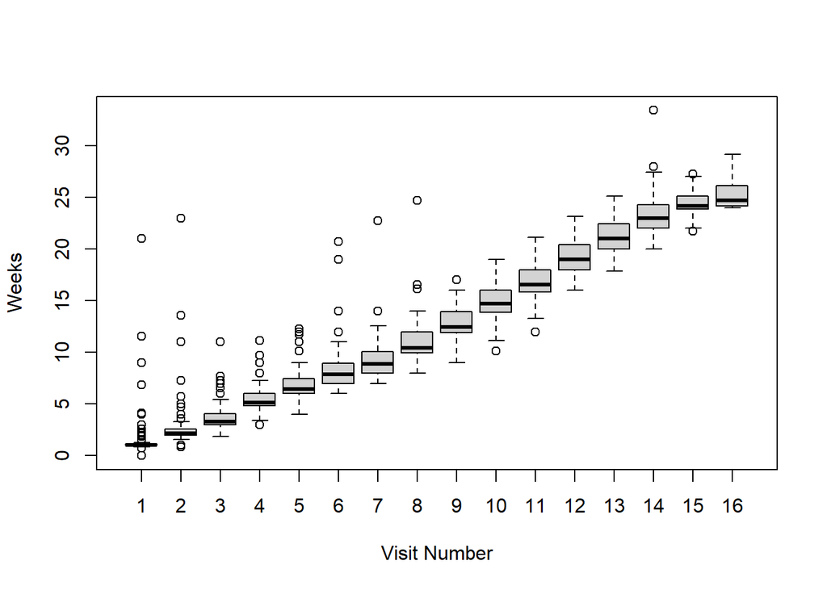

Figure 1: Weeks Since CHOP Started by Visit (Before Case Selection)

````markdown
```{r}
#| label: fig-visualize-weeks
#| fig-cap: Weeks Since CHOP Started by Visit (Before Case Selection)

boxplot(Weeks ~ Visit_Number, data = All_Visits, xlab="Visit Number")
```
````

## 3.3 Check Uniqueness of Visit Records

Next we verify that each row in the visit-level data (`All_Visits`) is a unique combination of a patient (`Patient`), a CHOP cycle (`CHOP_Number`), and a visit number (`Visit_Number`).

````markdown
```{r}
#| label: check-visit-uniqueness

# We expect a value of TRUE for Matching_N.
tibble(All_Visits_N = nrow(All_Visits),
       Unique_Visits_N = All_Visits %>%
         select(Patient, CHOP_Number, Visit_Number) %>%
         n_distinct(),
       Matching_N = All_Visits_N == Unique_Visits_N)
```
````

```
# A tibble: 1 × 3
  All_Visits_N Unique_Visits_N Matching_N
         <int>           <int> <lgl>
1         1007            1007 TRUE
```

**Tip**

If `Matching_N = TRUE` in the result immediately above, that confirms the uniqueness of each visit record.

## 3.4 Create Patient-Level Dataset

The `All_Visits` dataset has multiple rows per patient because the CHOP protocol involves multiple visits, each of which is recorded as a separate visit number. We need a patient-level data file to correctly get descriptive statistics on patient weight and body surface area.

````markdown
```{r}
#| label: create-All-Patients

All_Patients <- All_Visits %>%
  arrange(Patient, CHOP_Number, Visit_Number) %>%
  select(Patient, In_Final_Patients, Age_Yrs, Sex, Neutered, Breed,
         Diagnosis, Stage, Substage, Phenotype, Weight_kg, Surface_Area_m2) %>%
  group_by(Patient) %>%
  slice_head(n = 1) %>%
  ungroup()
```
````

Next, we verify that the number of rows in `All_Patients` is equal to the number of unique MRNs in `All_Visits`). If that is true, then all rows in `All_Visits` for a given `Patient` must have the exact same values for both weight and surface area.

**Caution**

After switching to the final data file that excluded `MRN`, I disabled the chunk below. We retain internal team documentation of the results of running it in date-stamped output from 2026-01-17, which used the 2026-01-16 version of the data. The code remains here to show how we checked assumptions previously.

````markdown
```{r}
#| label: check-patient-N
#| eval: FALSE

# We expect a value of TRUE for Matching_N.
tibble(All_MRNs_N = All_Visits %>% select(MRN) %>% n_distinct(),
       All_Patients_N = nrow(All_Patients),
       Matching_N = All_MRNs_N == All_Patients_N)
```
````

**Tip**

If `Matching_N = TRUE` in the result immediately above, that confirms number of rows in `All_Patients` is equal to the number of unique MRNs in `All_Visits`.

## 3.5 Create More Variables

After reading peer review feedback on a manuscript that got rejected, the team decided on 2024-08-29 to narrow the focus of the analyses. We will now focus only on data for patients who had their first visit within 10 days of their CHOP start date. This section creates variables we can use to implement that decision.

First we create a subset of the data containing only records for visit 1 within the respective CHOP cycles, then add a logical variable marking which visit 1 observations had `CBC_Dates` indicating that the lab sample was collected within 10 days of the start of that CHOP cycle.

````markdown
```{r}
#| label: create-Visit1-CHOP

Visit1_CHOP <- All_Visits %>%
  filter(Visit_Number == 1) %>%
  mutate(Started_in_10d = Days_Since_Start <= 10) %>%
  select(Patient, CHOP_Number, Started_in_10d)
```
````

Next we merge that new `Started_in_10d` variable back onto the `All_Visits` dataset. We can then use it later to select cases.

````markdown
```{r}
#| label: merge-All-Visits-Visit1-CHOP

All_Visits <- left_join(x = All_Visits, y = Visit1_CHOP,
                      by = join_by(Patient, CHOP_Number))
```
````

## 3.6 Subset the Visit-Level Data

In this section, we begin a sequential filtering process to get to the subset of records we want to analyze. Each step adds another filter that drops records. Before we start filtering, we store information on the amount of raw data before any filtering.

````markdown
```{r}
#| label: create-Step0

Step0 <- All_Visits %>%
  count(Patient) %>%
  summarise(Step = 0,
            Event = "Keep all records",
            N_Dogs = n(),
            N_Observations = sum(n))
```
````

### 3.6.1 By CHOP Cycle Number

In this step, we retain only records for the first CHOP cycle for each patient.

````markdown
```{r}
#| label: create-CHOP1

CHOP1 <- All_Visits %>%
  filter(CHOP_Number == 1)

Step1 <- CHOP1 %>%
  count(Patient) %>%
  summarise(Step = 1,
            Event = "Keep only records for CHOP cycle 1",
            N_Dogs = n(),
            N_Observations = sum(n))
```
````

The chunk below identified the list of patients removed by the filtering step above. This is just for reference in case the team wants to understand what happened there.

````markdown
```{r}
#| label: tbl-Step1-drops
#| tbl-cap: Records Dropped in Step 1 Subsetting

All_Visits %>%
  select(Patient, CHOP_Number) %>%
  filter(CHOP_Number != 1) %>%
  group_by(Patient, CHOP_Number) %>%
  summarize(Visits_Dropped = n()) %>%
  kable(digits = 2) %>%
  kable_styling()
```
````

Table 3: Records Dropped in Step 1 Subsetting

| Patient | CHOP_Number | Visits_Dropped |
| --- | --- | --- |
| 2 | 2 | 9 |
| 3 | 2 | 16 |
| 3 | 3 | 3 |
| 5 | 2 | 13 |
| 5 | 3 | 11 |
| 42 | 2 | 9 |
| 46 | 2 | 14 |
| 47 | 2 | 10 |
| 61 | 2 | 14 |
| 62 | 2 | 6 |
| 64 | 2 | 15 |
| 70 | 2 | 15 |
| 74 | 2 | 6 |
| 77 | 2 | 3 |
| 78 | 2 | 5 |
| 87 | 2 | 13 |
| 94 | 2 | 16 |

### 3.6.2 By Whether Visit 1 Occurred Within 10 Days of CHOP Cycle Starting

In this step, we retain only records for patients whose first visit during their first cycle started within 10 days of the CHOP cycle start date.

````markdown
```{r}
#| label: create-CHOP1-Start10d

CHOP1_Start10d <- CHOP1 %>%
  filter(Started_in_10d == TRUE)

Step2 <- CHOP1_Start10d %>%
  count(Patient) %>%
  summarise(Step = 2,
            Event = "Keep only if patient's visit 1 occurred within 10 days of CHOP start",
            N_Dogs = n(),
            N_Observations = sum(n))
```
````

The chunk below identified the list of patients removed by the filtering step above. This is just for reference in case the team wants to understand what happened there.

````markdown
```{r}
#| label: tbl-Step2-drops
#| tbl-cap: Records Dropped in Step 2 Subsetting

CHOP1 %>%
  filter(Started_in_10d == FALSE) %>%
  group_by(Patient) %>%
  summarise(Visits_Dropped = n(),
            CHOP1_Start_Date = min(CHOP_Start_Date),
            Visit1_CBC_Date = min(CBC_Date),
            Visit1_Weeks = min(Weeks)) %>%
  kable(digits = 2) %>%
  kable_styling()
```
````

Table 4: Records Dropped in Step 2 Subsetting

| Patient | Visits_Dropped | CHOP1_Start_Date | Visit1_CBC_Date | Visit1_Weeks |
| --- | --- | --- | --- | --- |
| 10 | 5 | 2022-09-29 | 2022-10-28 | 4.14 |
| 23 | 14 | 2022-06-27 | 2022-07-25 | 4.00 |
| 29 | 14 | 2019-01-21 | 2019-02-05 | 2.14 |
| 46 | 2 | 2017-08-11 | 2018-01-05 | 21.00 |
| 48 | 13 | 2022-07-07 | 2022-07-25 | 2.57 |
| 55 | 14 | 2020-02-11 | 2020-02-25 | 2.00 |
| 56 | 1 | 2022-10-19 | 2022-11-09 | 3.00 |
| 65 | 2 | 2019-04-18 | 2019-07-08 | 11.57 |
| 76 | 2 | 2019-11-14 | 2020-01-16 | 9.00 |
| 81 | 5 | 2022-09-20 | 2022-10-03 | 1.86 |
| 89 | 3 | 2021-05-03 | 2021-05-21 | 2.57 |
| 93 | 7 | 2021-01-18 | 2021-02-03 | 2.29 |
| 101 | 1 | 2021-05-13 | 2021-06-30 | 6.86 |
| 103 | 8 | 2021-06-08 | 2021-06-24 | 2.29 |
| 104 | 1 | 2021-06-28 | 2021-07-09 | 1.57 |
| 106 | 2 | 2022-01-24 | 2022-02-07 | 2.00 |
| 107 | 2 | 2022-01-24 | 2022-02-07 | 2.00 |
| 111 | 4 | 2022-11-18 | 2022-11-29 | 1.57 |

### 3.6.3 By Phase of Treatment

In this step, we retain only records where the visit occurred during the first phase of treatment

````markdown
```{r}
#| label: create-CHOP1-Start10d-Phase1

CHOP1_Start10d_Phase1 <- CHOP1_Start10d %>%
  filter(Phase_of_Trt == 1)

Step3 <- CHOP1_Start10d_Phase1 %>%
  count(Patient) %>%
  summarise(Step = 3,
            Event = "Keep only Phase 1 records",
            N_Dogs = n(),
            N_Observations = sum(n))
```
````

The chunk below identified the list of patients removed by the filtering step above. This is just for reference in case the team wants to understand what happened there.

````markdown
```{r}
#| label: tbl-Step3-drops
#| tbl-cap: Records Dropped in Step 3 Subsetting

CHOP1_Start10d %>%
  filter(Phase_of_Trt != 1) %>%
  group_by(Patient, Phase_of_Trt) %>%
  summarise(Visits_Dropped = n()) %>%
  kable(digits = 2) %>%
  kable_styling()
```
````

Table 5: Records Dropped in Step 3 Subsetting

| Patient | Phase_of_Trt | Visits_Dropped |
| --- | --- | --- |
| 3 | 2 | 7 |
| 5 | 2 | 6 |
| 7 | 2 | 1 |
| 8 | 2 | 5 |
| 12 | 2 | 6 |
| 19 | 2 | 5 |
| 27 | 2 | 6 |
| 30 | 2 | 5 |
| 31 | 2 | 6 |
| 32 | 2 | 6 |
| 35 | 2 | 3 |
| 38 | 2 | 7 |
| 39 | 2 | 2 |
| 42 | 2 | 6 |
| 44 | 2 | 7 |
| 49 | 2 | 6 |
| 52 | 2 | 2 |
| 54 | 2 | 2 |
| 57 | 2 | 6 |
| 61 | 2 | 3 |
| 62 | 2 | 5 |
| 64 | 2 | 6 |
| 66 | 2 | 6 |
| 68 | 2 | 5 |
| 70 | 2 | 6 |
| 71 | 2 | 5 |
| 73 | 2 | 6 |
| 74 | 2 | 6 |
| 77 | 2 | 6 |
| 78 | 2 | 5 |
| 80 | 2 | 5 |
| 84 | 2 | 1 |
| 87 | 2 | 7 |
| 90 | 2 | 2 |
| 94 | 2 | 6 |
| 96 | 2 | 6 |
| 97 | 2 | 5 |
| 99 | 2 | 2 |
| 100 | 2 | 1 |

### 3.6.4 By Drug

Here, we retain only the records where the drug associated with the visit was  
drug 1 (vincristine), drug 2 (cyclophosphamide), or drug 3 (doxorubicin). The drug selection is motivated by the fact that we don’t have enough data about other drugs.

````markdown
```{r}
#| label: create-CHOP1-Start10d-Phase1-Drug123

CHOP1_Start10d_Phase1_Drug123 <- CHOP1_Start10d_Phase1 %>%
  filter(Drug %in% 1:3)

Step4 <- CHOP1_Start10d_Phase1_Drug123 %>%
  count(Patient) %>%
  summarise(Step = 4,
            Event = "Keep only Drug 1, 2, & 3 records",
            N_Dogs = n(),
            N_Observations = sum(n))
```
````

The chunk below identified the list of patients removed by the filtering step above. This is just for reference in case the team wants to understand what happened there.

````markdown
```{r}
#| label: tbl-Step4-drops
#| tbl-cap: Records Dropped in Step 3 Subsetting

CHOP1_Start10d_Phase1 %>%
  filter(!Drug %in% 1:3) %>%
  group_by(Patient, Drug) %>%
  summarise(Visits_Dropped = n()) %>%
  kable(digits = 2) %>%
  kable_styling()
```
````

Table 6: Records Dropped in Step 3 Subsetting

| Patient | Drug | Visits_Dropped |
| --- | --- | --- |
| 1 | 4 | 2 |
| 19 | 4 | 1 |
| 43 | 5 | 2 |
| 91 | 4 | 1 |
| 92 | 4 | 1 |
| 105 | 4 | 3 |
| 105 | 6 | 1 |

### 3.6.5 Rename Data Frame

Here we rename the data object to keep the object name shorter.

````markdown
```{r}
#| label: create-Final-Visits

Final_Visits <- CHOP1_Start10d_Phase1_Drug123
```
````

There are 530 rows in `Final_Visits`.

## 3.7 Subset the Patient-Level Data

We aggregate data from `Final_Visits` to count how many visits each dog has so  
we can merge that into the final patient-level data.

````markdown
```{r}
#| label: create-Visit-Counts

Visit_Counts <- Final_Visits %>%
  count(Patient) %>%
  rename(N_Visits = n)
```
````

There are 90 rows in `Visit_Counts`.

Next, we need to merge in a patient-level version of `Leukemic` because that should be time-invariant within a CHOP cycle.

````markdown
```{r}
#| label: create-Leukemic

Leukemic <- Final_Visits %>%
  select(Patient, Leukemic) %>%
  unique()
```
````

There are 90 rows in `Leuklemic`.

Now we trim the `All_Patients` data down to just the patients included in the `Final_Visits` data frame and merge it with `Visit_Counts` and `Leuklemic`.

````markdown
```{r}
#| label: create-Final-Patients

Final_Patients <- All_Patients %>%
  filter(Patient %in% Final_Visits$Patient) %>%
  left_join(x = ., y = Visit_Counts, by = join_by(Patient)) %>%
  left_join(x = ., y = Leukemic, by = join_by(Patient))
```
````

There are 90 rows in `Final_Patients`.

# 4 Summarize Amount of Data Remaining

Now Table 7 summarizes how much data there was at each step of record selection.

````markdown
```{r}
#| label: tbl-amt-data
#| tbl-cap: Amount of Data Available By Step in Case Selection

bind_rows(Step0, Step1, Step2, Step3, Step4) %>%
  mutate(Mean_Obs_Per_Dog = N_Observations/N_Dogs) %>%
  kable(digits = 1) %>%
  kable_styling()
```
````

Table 7: Amount of Data Available By Step in Case Selection

| Step | Event | N_Dogs | N_Observations | Mean_Obs_Per_Dog |
| --- | --- | --- | --- | --- |
| 0 | Keep all records | 110 | 1007 | 9.2 |
| 1 | Keep only records for CHOP cycle 1 | 108 | 829 | 7.7 |
| 2 | Keep only if patient's visit 1 occurred within 10 days of CHOP start | 90 | 729 | 8.1 |
| 3 | Keep only Phase 1 records | 90 | 541 | 6.0 |
| 4 | Keep only Drug 1, 2, & 3 records | 90 | 530 | 5.9 |

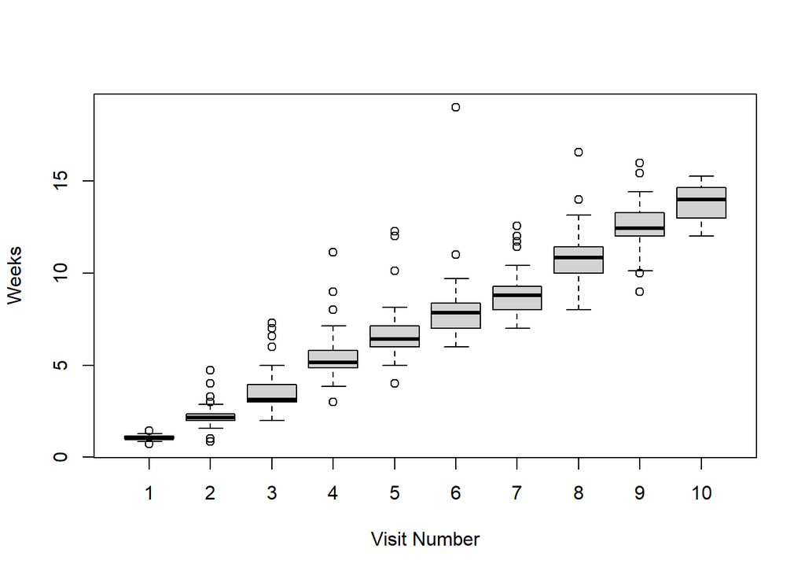

Figure 2: Weeks Since CHOP Started By Visit Number (After Case Selection)

````markdown
```{r}
#| label: fig-visualize-weeks-again
#| fig-cap: Weeks Since CHOP Started By Visit Number (After Case Selection)

boxplot(Weeks ~ Visit_Number, data = CHOP1_Start10d_Phase1_Drug123,
        xlab="Visit Number")
```
````

````markdown
```{r}
#| label: tbl-visit-drug
#| tbl-cap: Number of Records by Visit and Drug (After Case Selection)

xtabs(~Visit_Number + Drug, data = CHOP1_Start10d_Phase1_Drug123) %>%
  addmargins() %>%
  kable(col.names = c("Visit", "1 Vincristine", "2 Cyclophosphamide",
                      "3 Doxorubicin", "Sum")) %>%
  kable_styling() %>%
  add_header_above(., header = c(" ", "Drug" = 3, " "))
```
````

Table 8: Number of Records by Visit and Drug (After Case Selection)

| Visit | Drug 1 Vincristine | Drug 2 Cyclophosphamide | Drug 3 Doxorubicin | Sum |
| --- | --- | --- | --- | --- |
| 1 | 79 | 8 | 1 | 88 |
| 2 | 15 | 64 | 0 | 79 |
| 3 | 55 | 6 | 10 | 71 |
| 4 | 10 | 1 | 48 | 59 |
| 5 | 46 | 7 | 4 | 57 |
| 6 | 14 | 33 | 1 | 48 |
| 7 | 33 | 3 | 8 | 44 |
| 8 | 9 | 3 | 29 | 41 |
| 9 | 30 | 7 | 3 | 40 |
| 10 | 1 | 2 | 0 | 3 |
| Sum | 292 | 134 | 104 | 530 |

# 5 Update Visit-Level Data

Here we finally add some derived variables we will need for the planned GLMM analyses.

````markdown
```{r}
#| label: update-Final-Visits

Final_Visits <- Final_Visits %>%
  # Dummy-code Drug (using Drug = 1 (vincristine) as reference level)
  mutate(DrugV = if_else(Drug == 1, true = 1, false = 0),
         DrugC = if_else(Drug == 2, true = 1, false = 0),
         DrugD = if_else(Drug == 3, true = 1, false = 0)) %>%
  # Turn on grouping by patient so we can easily get patient-level means.
  group_by(Patient) %>%
  # Aggregate dummy codes to patient-level means for use in GLMM analyses.
  mutate(M_DrugV = mean(DrugV),
         M_DrugC = mean(DrugC),
         M_DrugD = mean(DrugD)) %>%
  # Turn off grouping by patient (no longer need it)
  ungroup() %>%
  # Create centered L1 predictors for use in GLMM analyses.
  mutate(DrugV_C = DrugV - M_DrugV,
         DrugC_C = DrugC - M_DrugC,
         DrugD_C = DrugD - M_DrugD) %>%
  # Center the L2 predictors for use in GLMM analyses.
  mutate(BSA_m2_C = Surface_Area_m2 - mean(Final_Patients$Surface_Area_m2),
         Age_Yrs_C = Age_Yrs - mean(Age_Yrs)) %>%
  set_variable_labels(DrugV = "Dummy code, Drug = Vincristine (L1, uncentered)",
                      DrugC = "Dummy code, Drug = Cyclophosphamide (L1, uncentered)",
                      DrugD = "Dummy code, Drug = Doxorubicin (L1, uncentered)",
                      M_DrugV = "Mean dummy code, Drug = Vincristine (L2, aggregated)",
                      M_DrugC = "Mean dummy code, Drug = Cyclophosphamide (L2, aggregated)",
                      M_DrugD = "Mean dummy code, Drug = Doxorubicin (L2, aggregated)",
                      DrugV_C = "Dummy code, Drug = Vincristine (L1, group mean centered)",
                      DrugC_C = "Dummy code, Drug = Cyclophosphamide (L1, group mean centered)",
                      DrugD_C = "Dummy code, Drug = Doxorubicin (L1, group mean centered)",
                      BSA_m2_C = "Body surface area in m^2 (L2, grand-mean centered)")
```
````

# 6 Update Patient-Level Data

We want the add the means for the dummy-coded drug variables to the patient data for use in some graphs later.

````markdown
```{r}
#| label: create-Drug-Means

Drug_Means <- Final_Visits %>%
  select(Patient, M_DrugV, M_DrugC, M_DrugD) %>%
  unique() %>%
  set_variable_labels(M_DrugV = "Mean dummy code, Drug = Vincristine (L2, aggregated)",
                      M_DrugC = "Mean dummy code, Drug = Cyclophosphamide (L2, aggregated)",
                      M_DrugD = "Mean dummy code, Drug = Doxorubicin (L2, aggregated)")
```
````

````markdown
```{r}
#| label: update-Final-Patients

Final_Patients <- Final_Patients %>%
  left_join(x = ., y = Drug_Means, by = join_by(Patient))
```
````

# 7 Save Data

````markdown
```{r}
#| label: create-save-what

# Character vector of object names that will be saved.
save_what <- c("Raw_Visits", "All_Visits", "All_Patients", "Final_Visits",
               "Final_Patients")
```
````

````markdown
```{r}
#| label: save-data
#| execute: true

DataFile <- here("data/Imported_CHOP_Data.RData")

save(list = save_what, file = DataFile)
```
````

Table 9 shows meta-data about the data file we just saved.

````markdown
```{r}
#| label: tbl-imported-data-file
#| tbl-cap: "Meta-Data About the Imported Data File Saved Out"

file_details(DataFile) %>%
  kable(, format = "html",
        col.names = c("File Name", "Size", "Last Modified")) %>%
  kable_styling()
```
````

Table 9: Meta-Data About the Imported Data File Saved Out

| File Name | Size | Last Modified |
| --- | --- | --- |
| Imported_CHOP_Data.RData | 63.8K | 2026-01-29 13:45:43 |

**Tip**

The current data file can be loaded into R by copying the following code chunk into a script, setting the chunk option `eval: true`, and running the chunk. That will overwrite any objects already in memory that have the same names as the objects being loaded.

````markdown
```{r}
#| label: load-data
#| eval: false

load(file=here("data/Imported_CHOP_Data.RData"))
```
````

# 8 References

Eliason, C. N., Pierce, S. J., & Masyr, A. (2026). *Band neutrophils are observed in dogs undergoing multiagent chemotherapy including vincristine* [Manuscript accepted for publication]. Department of Small Animal Clinical Sciences, Michigan State University.

Pierce, S. J. (2026). *CHOPStudy: Research compendium for the CHOP study* (Version 1.0.3) [Reproducible Research Materials, Computer Program, R package, Public Repository]. GitHub. https://github.com/sjpierce/CHOPStudy. Zenodo. https://doi.org/10.5281/zenodo.18381003

# 9 Software Information

This section documents information that is important for reproducibility. Most users will not need to read it. It is primarily here for use by the statistician on the team.

We used [R](https://www.r-project.org/) as our main computing environment and [Quarto](https://quarto.org/) scripts to enhance reproducibility. We used RStudio as the editor to interface with R and Quarto.

- Software chain: **qmd file > RStudio > Quarto > R > knitr > md file > Pandoc > HTML file**.
- Source file: **Import_Data.qmd**
- Output file: **Import_Data_2026-01-29.html**
- [Quarto 1.8.27](https://quarto.org/) runs `*.qmd` files through [R](https://www.r-project.org/) and [knitr](https://yihui.org/knitr/) to produce `*.md` markdown files.
- [Pandoc 3.6.3](https://pandoc.org) converts markdown files (`*.md`) to other formats, including LaTeX (`*.tex`) and HTML (`*.html`) among others.

## 9.1 Versions

## 9.2 Git Details

The current Git commit details and status are:

```r
git_report()
```

```
Local:    main P:/Consulting/Cases_1200-1399/C1358/CHOPStudy
Remote:   main @ origin (https://github.com/sjpierce/CHOPStudy.git)
Head:     [e5b6ca2] 2026-01-29: Update news.
```

```
Untracked files:
    Untracked:  scripts/Import_Data.rmarkdown
    Untracked:  scripts/Import_Data_files/
    Untracked:  scripts/Render_Scripts.rmarkdown
```